# Die kleine Meerjungfrau - Die Hamburgische Staatsoper

[Die Hamburgische Staatsoper](https://www.die-hamburgische-staatsoper.de/de)

[figure not shown]

Foto: Kiran West

[Programm](https://hamburgballett.die-hamburgische-staatsoper.de/de/programm/) → Ballett

# Die kleine Meerjungfrau

John Neumeier

- Sa 18.10. 19:30 Tickets
- Di 21.10. 19:30 Tickets
- Do 23.10. 19:30 Tickets
- Fr 31.10. 18:00 Tickets
- So 2.11. 18:00 Tickets
- Mi 5.11. 19:30 Tickets
- Zum letzten Mal in dieser Spielzeit

  Sa 8.11. 19:30 Tickets

John Neumeier kreierte dieses Märchenballett mit dem Königlich Dänischen Ballett zur Feier des 200. Geburtstages des dänischen Dichters Hans Christian Andersen. Neumeier schuf eine moderne doch auch zeitlose Interpretation der kleinen Meerjungfrau – ein dramatisches Märchenszenario, das in zwei gegensätzlichen Welten spielt. Lera Auerbach komponierte die Musik für großes Orchester zu diesem Ballett.

## „Du bist es, die mich gerettet hat.“

Ballett von John Neumeier frei nach Hans Christian Andersen  
Uraufführung: Königlich Dänisches Ballett, Opernhaus, Kopenhagen, 15. April 2005  
Premiere in Hamburg: Hamburg Ballett, 1. Juli 2007

[interactive chart not shown]

## Besetzung

- Choreografie und Inszenierung

  [John Neumeier](https://hamburgballett.die-hamburgische-staatsoper.de/de/personen/707-john-neumeier)
- Musik

  [Lera Auerbach](https://hamburgballett.die-hamburgische-staatsoper.de/de/personen/3848-lera-auerbach)
- Kostüme und Bühnenbild

  [John Neumeier](https://hamburgballett.die-hamburgische-staatsoper.de/de/personen/707-john-neumeier)
- Musikalische Leitung

  [Luciano Di Martino](https://hamburgballett.die-hamburgische-staatsoper.de/de/personen/4905-luciano-di-martino)
- Ensemble

  Hamburg Ballett
- Orchester

  [Philharmonisches Staatsorchester Hamburg](https://hamburgballett.die-hamburgische-staatsoper.de/de/personen/1929-philharmonisches-staatsorchester-hamburg)

[figure not shown]

- **© ×**

  Kiran West

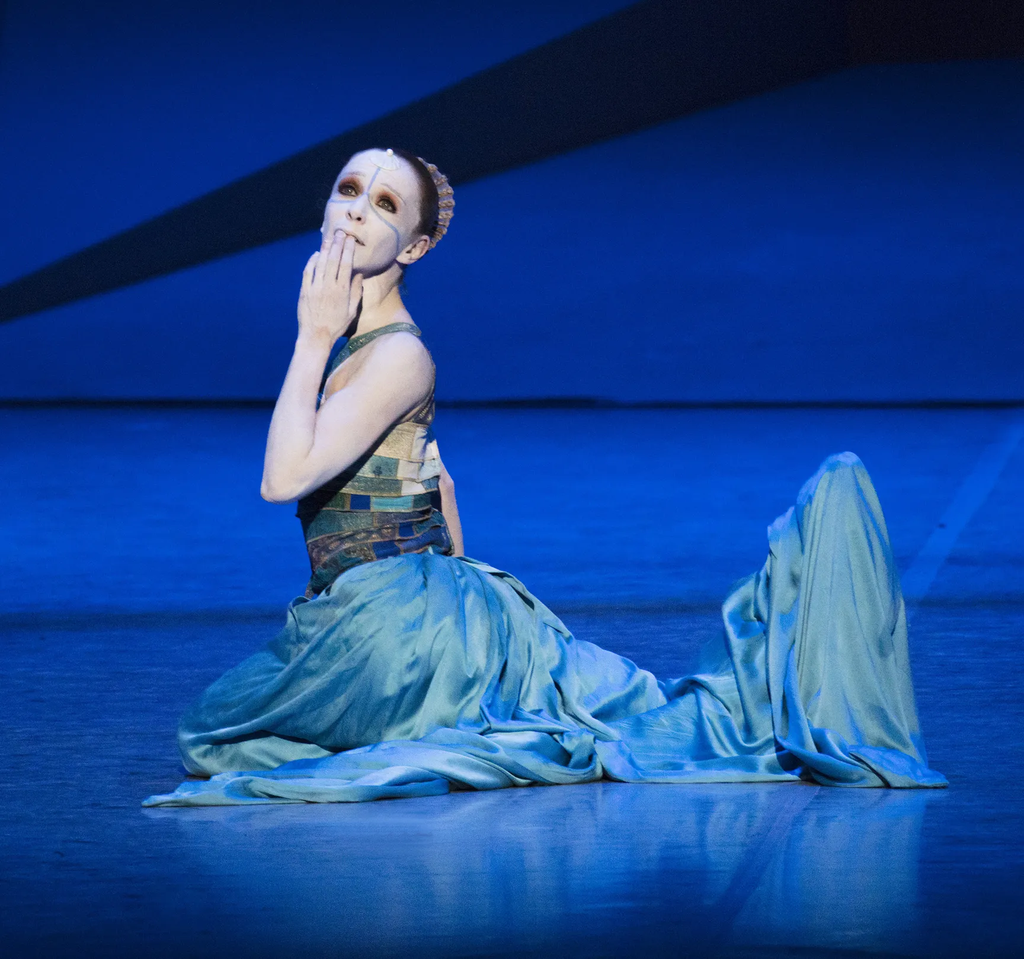

- **© ×**

  Kiran West

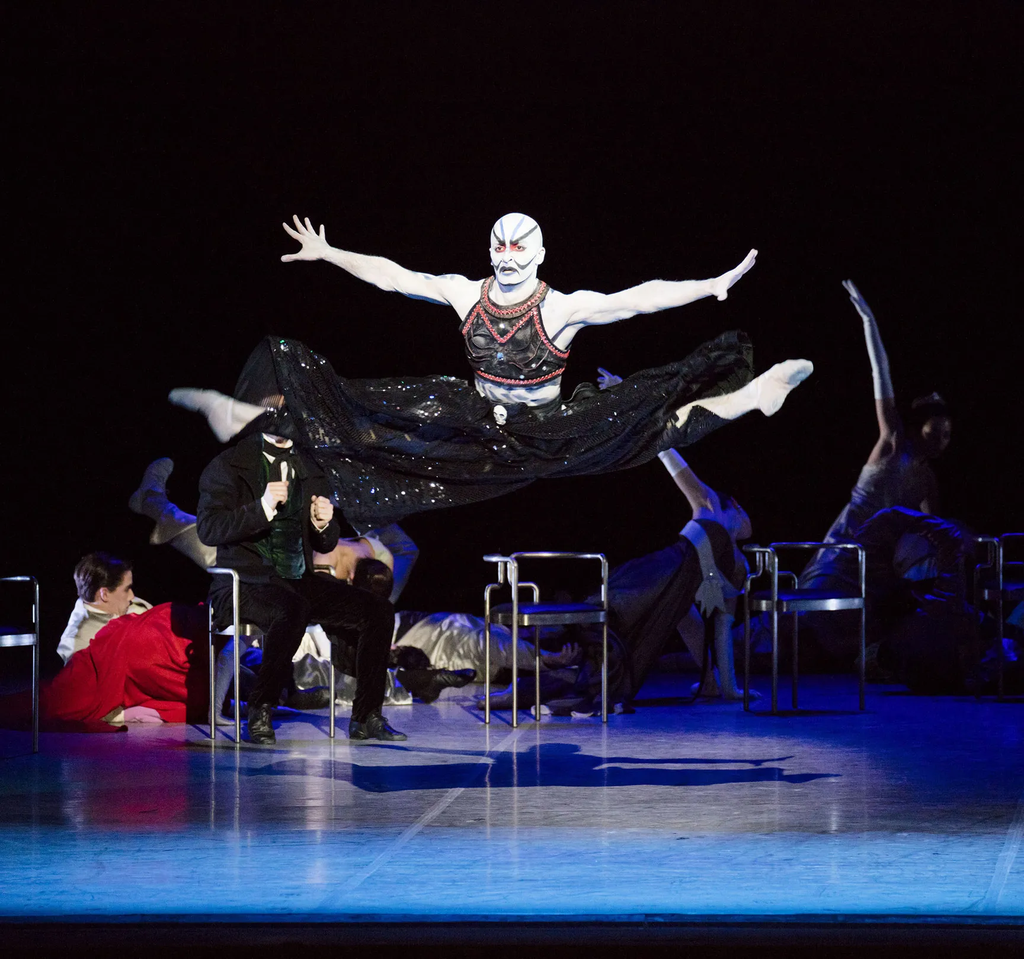

- **© ×**

  Kiran West

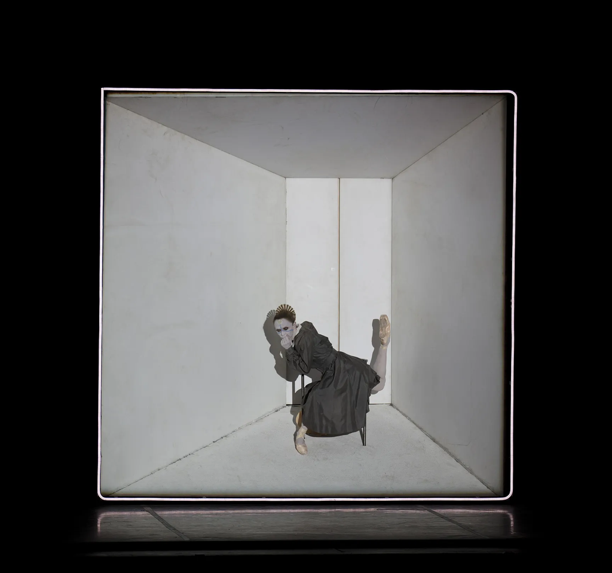

- **© ×**

  Kiran West

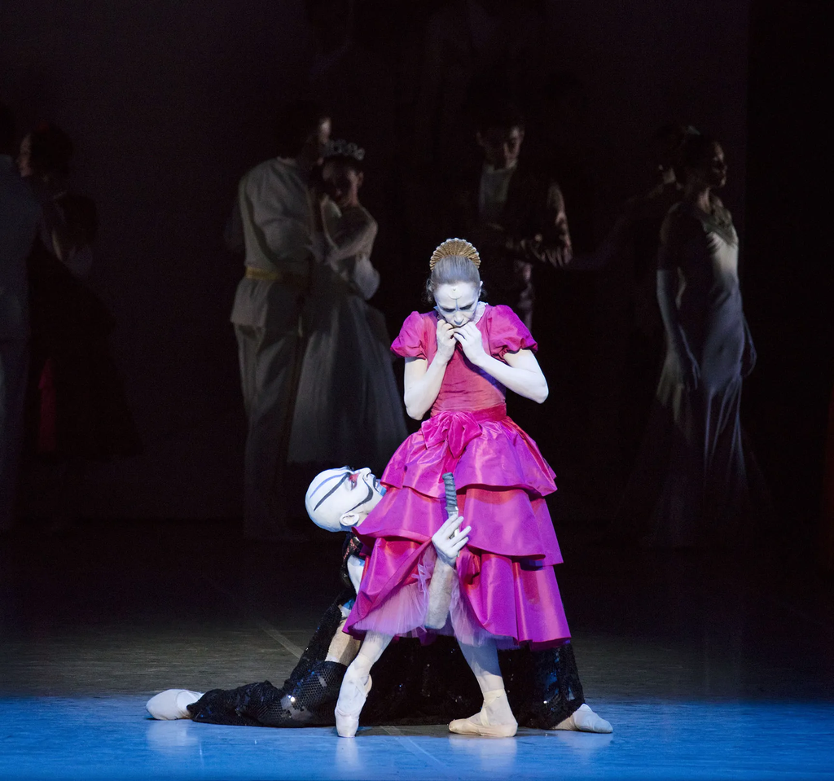

- **© ×**

  Kiran West

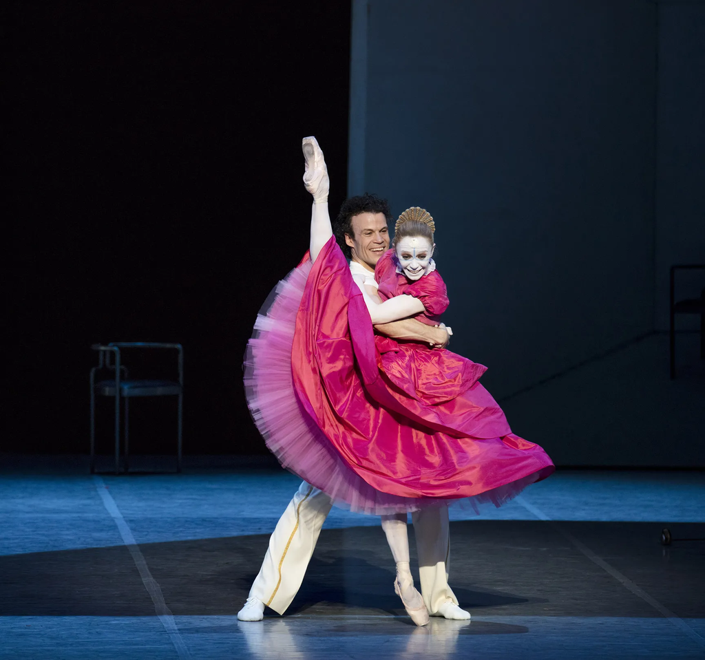

- **© ×**

  Kiran West

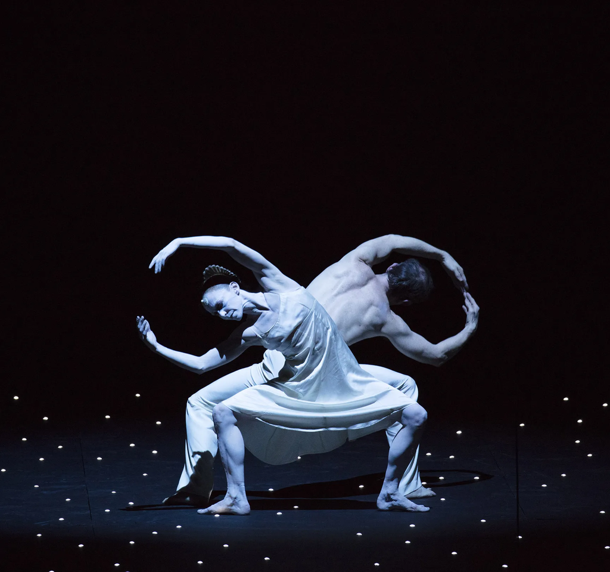

- **© ×**

  Kiran West

[figure not shown]

- **© ×**

  Kiran West

[figure not shown]

- **© ×**

  Kiran West

## Das Stück

- Spielstätte Staatsoper, Großes Haus
- Dauer 150 Min
- Pause 1 Pause / 1. Teil: 75 Minuten, 2. Teil: 45 Minuten
- Altersempfehlung Ab 13 Jahren / Klasse 8

Die schlichte Unterwasserwelt der Meereswesen bildet einen gewaltigen Kontrast zum pompösen Leben der Menschen auf dem trockenen Land. Die zentrale Figur der Meerjungfrau reist durch beide Welten und erträgt in ihrer bedingungslosen Liebe zum Prinzen endloses Leid – durch ihre eigene Stärke findet sie am Ende Erlösung. Das Ballett unterstreicht die Parallelen des Märchens zu Hans Christian Andersens eigener Biographie.  
"Die kleine Meerjungfrau" ersetzt "Surrogate Cities".  
Bitte beachten Sie: Eintrittskarten für die vormals angekündigten Vorstellungen "Demian" und "Surrogate Cities" gelten unverändert weiter für den jeweiligen Vorstellungstermin.

- Mit freundlicher Unterstützung durch die

[figure not shown]

**Inhaltsangabe − +**

PROLOG

Während einer Seereise erinnert sich der Dichter an die Hochzeit Edvards mit Henriette. Eine Träne rinnt langsam über seine Wange und fließt in ein Meer von Erinnerungen und Phantasien.

TEIL 1

Auf dem Meeresgrund nimmt des Dichters Sehnsucht nach Edvard die Gestalt der kleinen Meerjungfrau an, die oben auf der Meeresoberfläche ein Schiff erblickt und von der Welt der Erde träumt. An Bord des Schiffes üben Matrosen. Ihr Kapitän – ein Prinz, der Edvard stark ähnelt – spielt absurder Weise Golf. Als er den Ball über die Reling schlägt, taucht er in die See. Obwohl er sie nicht sehen kann, umfängt die Meerjungfrau ihn wie ein Hauch von Duft.

Der Meerhexer tritt auf und ein heftiger Sturm setzt ein. Der Prinz wäre wohl ertrunken, wenn ihn nicht die kleine Meerjungfrau durch den Willen des Dichters gerettet hätte. Sie küsst ihn.

Glockengeläut. An der Küste erscheint eine Gruppe Klosterschülerinnen. Eine von ihnen, die Prinzessin – die zudem Henriette sehr auffällig gleicht –, entdeckt den bewusstlosen Prinzen. Vorsichtig weckt sie ihn. Der Prinz glaubt, dass sie ihn gerettet hat und scheint sich in sie zu verlieben.

Traurig und verzagt wird die kleine Meerjungfrau Zeugin der aufkeimenden Zuneigung zwischen Prinz und Prinzessin. Ihr Verlangen wendet sich in Verzweiflung und spiegelt darin die Seele des Dichters.

Ihr Entschluss, ein Mensch zu werden, führt sie zum Meerhexer. Ihre Liebe gibt der kleinen Meerjungfrau Mut, ihn um einen menschlichen Körper zu bitten – koste es, was es wolle. Gewaltsam verwandelt der Meerhexer die kleine Meerjungfrau. Sie hat Beine...

Nackt erwacht sie an der Küste und leidet mit ihren ersten Schritten unerträgliche Qualen. Der junge Prinz taucht auf, hat Mitleid mit ihrem seltsamen Wesen und trägt sie auf sein Schiff. Ihr Traum scheint sich zu erfüllen.

Zwischen den Passagieren des Schiffes entdeckt der Prinz die Prinzessin. Je mehr sich die Liebe zwischen den beiden steigert, um so mehr erduldet die kleine Meerjungfrau menschliches Leiden.

TEIL 2

Die kleine Meerjungfrau will unbedingt ein Mensch sein, aber in den Räumen auf der Erde leidet sie unter Platzangst. Trotz ihrer Anstrengungen ist sie in ihrem menschlichen Körper immer noch ungeschickt und unförmig. Visionen des Meereslebens durchkreuzen ihre Träume...

In ihrer großen Liebe zum Prinzen wird ihr Verlangen, dass auch er sie liebt, gänzlich vergebens, denn heute wird er die Prinzessin heiraten – die kleine Meerjungfrau soll eine Brautjungfer sein. Während der Feier erscheint der Meerhexer als Teil einer seltsamen Unterhaltung. Er gibt ihr ein scharfes Messer und verspricht, wenn sie den Prinzen töte, könne sie ihre Schwanzflosse wiedererlangen und nach Hause in die Tiefen des Meeres zurückkehren.

Es wird aber klar, dass sie ihm niemals wehtun kann. Fühlt er während des Abschieds für einen Augenblick die Glut ihrer Leidenschaft? Küssen sie sich? Abrupt wendet sich der Prinz von der kleinen Meerjungfrau und entfernt sich zur Hochzeitsnacht mit der Prinzessin.

EPILOG

Die kleine Meerjungfrau bleibt allein zurück. Ihre Schmerzen reflektieren die betrübte Situation des Dichters. Einer scheint der Schatten des anderen zu sein. Schöpfer und Schöpfung sind eins. Die Liebe des Dichters zu seiner kleinen Meerjungfrau gibt ihr schließlich eine Seele, die sie unsterblich macht, wie auch seine Kreation ihn zur Unsterblichkeit verhilft. Furchtlos begeben sie sich auf die Suche nach einer neuen Welt.

**Historische Stückinfos − +**

URAUFFÜHRUNG:  
Königlich Dänisches Ballett, Opernhaus, Kopenhagen, 15. April 2005  
PREMIERE IN HAMBURG:  
Hamburg Ballett, 1. Juli 2007  
ORIGINALBESETZUNG:  
Der Dichter: Mogens Boesen  
Die kleine Meerjungfrau: Marie-Pierre Greve  
Edvard/Der Prinz: Kenneth Greve  
Henriette/Die Prinzessin: Gudrun Bojesen  
Der Meerhexer: Jean-Lucien Massot  
GASTSPIELE:  
2009 Nagoya, Nishinomiya, Tokio 2013 Costa Mesa (CA), Baden-Baden 2017 Washington  
IM REPERTOIRE:  
Houston Ballet  
Joffrey Ballet  
Königlich Dänisches Ballett  
San Francisco Ballet  
Stanislawski- und Nemirowitsch-Dantschenko-Musiktheater  
The National Ballet of China

- Mit: [Luciano Di Martino](https://hamburgballett.die-hamburgische-staatsoper.de/de/personen/4905-luciano-di-martino), Hamburg Ballett, [Philharmonisches Staatsorchester Hamburg](https://hamburgballett.die-hamburgische-staatsoper.de/de/personen/1929-philharmonisches-staatsorchester-hamburg)

  [Details](https://hamburgballett.die-hamburgische-staatsoper.de/de/programm/ballett/566-die-kleine-meerjung-shy-frau)
- Mit: [Luciano Di Martino](https://hamburgballett.die-hamburgische-staatsoper.de/de/personen/4905-luciano-di-martino), Hamburg Ballett, [Philharmonisches Staatsorchester Hamburg](https://hamburgballett.die-hamburgische-staatsoper.de/de/personen/1929-philharmonisches-staatsorchester-hamburg)

  [Details](https://hamburgballett.die-hamburgische-staatsoper.de/de/programm/ballett/566-die-kleine-meerjung-shy-frau)
- Mit: [Luciano Di Martino](https://hamburgballett.die-hamburgische-staatsoper.de/de/personen/4905-luciano-di-martino), Hamburg Ballett, [Philharmonisches Staatsorchester Hamburg](https://hamburgballett.die-hamburgische-staatsoper.de/de/personen/1929-philharmonisches-staatsorchester-hamburg)

  [Details](https://hamburgballett.die-hamburgische-staatsoper.de/de/programm/ballett/566-die-kleine-meerjung-shy-frau)
- Mit: [Luciano Di Martino](https://hamburgballett.die-hamburgische-staatsoper.de/de/personen/4905-luciano-di-martino), Hamburg Ballett, [Philharmonisches Staatsorchester Hamburg](https://hamburgballett.die-hamburgische-staatsoper.de/de/personen/1929-philharmonisches-staatsorchester-hamburg)

  [Details](https://hamburgballett.die-hamburgische-staatsoper.de/de/programm/ballett/566-die-kleine-meerjung-shy-frau)
- Mit: [Luciano Di Martino](https://hamburgballett.die-hamburgische-staatsoper.de/de/personen/4905-luciano-di-martino), Hamburg Ballett, [Philharmonisches Staatsorchester Hamburg](https://hamburgballett.die-hamburgische-staatsoper.de/de/personen/1929-philharmonisches-staatsorchester-hamburg)

  [Details](https://hamburgballett.die-hamburgische-staatsoper.de/de/programm/ballett/566-die-kleine-meerjung-shy-frau)
- Mit: [Luciano Di Martino](https://hamburgballett.die-hamburgische-staatsoper.de/de/personen/4905-luciano-di-martino), Hamburg Ballett, [Philharmonisches Staatsorchester Hamburg](https://hamburgballett.die-hamburgische-staatsoper.de/de/personen/1929-philharmonisches-staatsorchester-hamburg)

  [Details](https://hamburgballett.die-hamburgische-staatsoper.de/de/programm/ballett/566-die-kleine-meerjung-shy-frau)
- Mit: [Luciano Di Martino](https://hamburgballett.die-hamburgische-staatsoper.de/de/personen/4905-luciano-di-martino), Hamburg Ballett, [Philharmonisches Staatsorchester Hamburg](https://hamburgballett.die-hamburgische-staatsoper.de/de/personen/1929-philharmonisches-staatsorchester-hamburg)

  [Details](https://hamburgballett.die-hamburgische-staatsoper.de/de/programm/ballett/566-die-kleine-meerjung-shy-frau)

[interactive chart not shown]